# Assignment 4

Yani Pohl and Marie Bouffard

11/15/2019

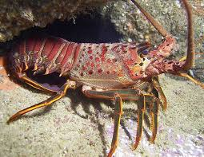

California Spiny Lobster *(Panulirus interruptus)* [*(Credit: Catalina Island Marine Institute)*](https://cimioutdoored.org/ca-spiny-lobster/)

### Introduction

California’s Marine Protected Area (MPA) Management Program aims to protect the integrity of the state’s marine ecosystems through the establishment of a network of protected areas along the California coast. (California Department of Fish and Wildlife) In order to ensure that MPA’s meet program goals, and to facilitate effective adaptive management, selected sites have ongoing monitoring, research, and evaluation projects. The Santa Barbara Coastal Long-term ecological research team (SBC LTER) is part of NSF’s Long Term Ecological Research Network and studies the giant kelp forests off the coast of southern California. (Reed D.2019.) SBC LTER studies five reef locations in Santa Barbara County. Two of these reefs, Naples and Isla Vista, are part of the California MPA network and were established as MPA sites on January 1st, 2012. The other three reefs, Arroyo Quemado, Mohawk and Carpinteria, are outside MPAs. The California spiny lobster (Panulirus interruptus) is an important predator for kelp forest ecosystems so understanding how fishing impacts their populations is critical for managing California’s coastal kelp forest community dynamics. Abundance and size data on these lobsters in these five reefs provides a comparison for how lobster population health has changed in in MPA and non-MPA reefs in the six years since the MPAs were established.

[figure not shown]

Location of SBC LTER sampling sites (2012-2018) [*(Credit: Santa Barbara Coastal Term Ecological Research program)*](https://sbclter.msi.ucsb.edu/)

### Data and Methods

Data for Spiny Lobster abundance and sizes was collected and provided by the SBC LTER program. Divers measured abundance and size (mm) in summer before the start of fishing season at five sites along the coast of Santa Barbara. The number and size of spiny lobsters at each site were recorded by in four 300m^2 transects (60 x 5 m) at each site. Data collection begin in the summer of 2012 and was collected annually through 2018.

### Results

#### 1. Changes in Lobster Abundance by Site

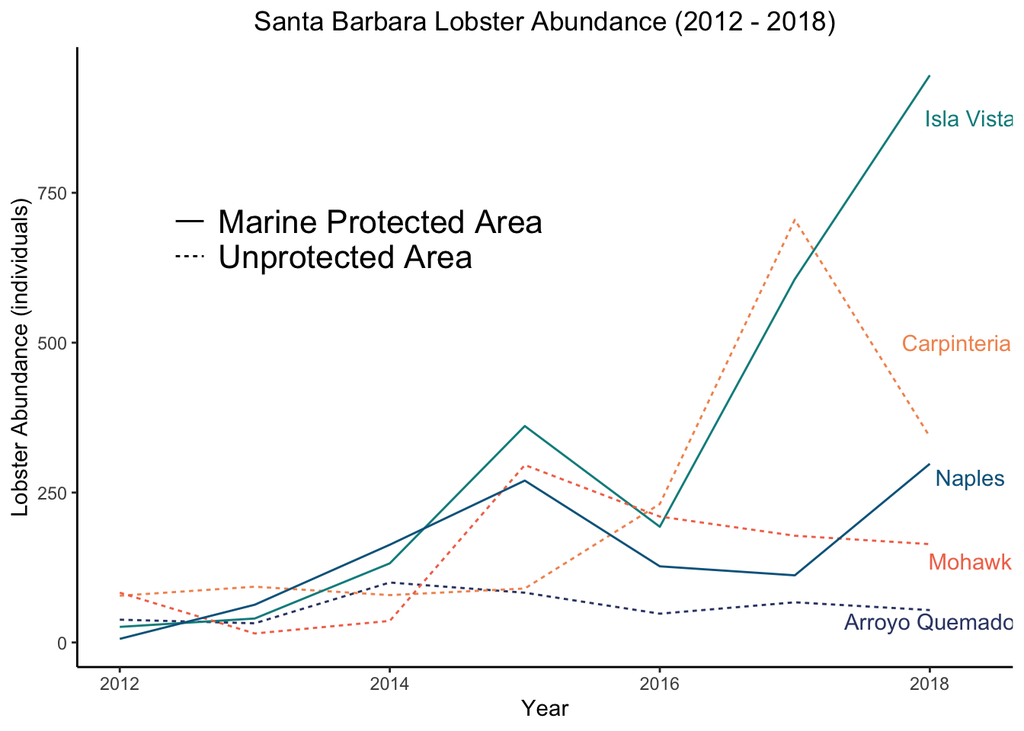

**Fig. 1** - *Lobster population counts at five sampling sites along the Santa Barbara coast (2012 - 2018). Solid lines indicate that survey site is a marine protected area, dashed lines are unprotected sites and line color indicates survey location.*

#### 2. Lobster Size Distribution in 2012 and 2018

Isla Vista and Naples, the reef sites within Marine Protected Areas, saw an overall increase in lobster size for the entire population from 2012 to 2018. The number of lobsters above 80 mm (approximate minimum catch size) increased significantly at Isla Vista between 2012 and 2018. At unprotected reef sites the distribution of size in the lobster populations is relatively unchanged in the same time period and the majority of lobsters in these population are smaller than the minimum catch size.

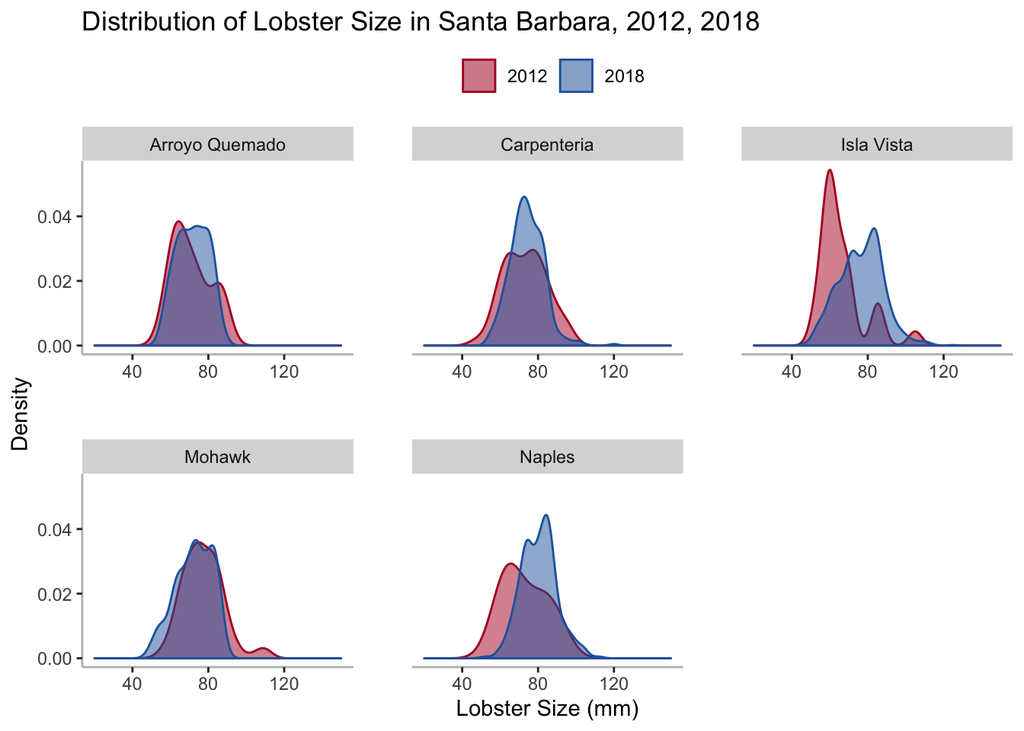

**Fig. 2** - *Lobster size distributions for five reef sites in Santa Barbara county in 2012 and 2018.*

#### 3. Comparing mean lobster sizes at MPA vs. non-MPA sites in 2012 and 2018

##### Comparison of lobster size between MPA and non-MPA sites in 2012

In 2012, lobsters at MPA sites had smaller mean size (67.38 $\pm$ 12.15, n = 32) than lobsters non-MPA sites (74.92 $\pm$ 12.41, n = 199) by a two-sided, two sample t-test (t(42.09) = -3.25, *p* = 0.002). With a moderate effect size (Cohen’s *d* = -0.61), the difference in mean lobster size in 2012 within MPA sites compared to non-MPA sites is noticeable upon careful review.

##### Comparison of lobster size between 2012 and 2018 in non-MPA sites

In 2012 lobsters at non MPA sites had a mean size of (74.92 $\pm$ 12.41, n = 199) which did not differ significantly from mean lobster size in non-MPA sites in 2018 (73.62 $\pm$ 10.09, n = 561) by a two-sided, two sample t-test (t(296.01) = 1.33, *p* = 0.183). With a small effect size (Cohen’s *d* = 0.12), the difference in mean lobster size within non-MPA sites in 2012 compared to non-MPA sites in 2018 is not noticeable.

**Table 1. Lobster size statistics for MPA and Non MPA site in 2012 and 2018.**

| Year | MPA Status | Mean (mm) | Standard Deviations (mm) | Sample Size (# of lobsters) |
| --- | --- | --- | --- | --- |
| 2012 | MPA | 67.38 | 12.15 | 32 |
| 2012 | Non MPA | 74.92 | 12.41 | 199 |
| 2018 | MPA | 77.57 | 11.70 | 1244 |
| 2018 | Non MPA | 73.62 | 10.09 | 561 |

### Reference

California Department of Fish and Wildlife. (2019). California Marine Protected Areas (MPAs). Retrieved from: https://www.wildlife.ca.gov/Conservation/Marine/MPAs

Reed D. 2019. SBC LTER: Reef: Abundance, size and fishing effort for California Spiny Lobster (Panulirus interruptus), ongoing since 2012. Environmental Data Initiative. https://doi.org/10.6073/pasta/a593a675d644fdefb736750b291579a0. Dataset accessed 11/17/2019.